# Lab 3

Justine Lang

2023-02-01

```r
knitr::opts_chunk$set(echo = TRUE, message = FALSE, warning = FALSE)

library(tidyverse)
library(tidymodels)
library(palmerpenguins)
library(GGally)
library(jtools)
library(AICcmodavg)
```

# 1. Binary logistic regression

## a. Exploration with `ggpairs`

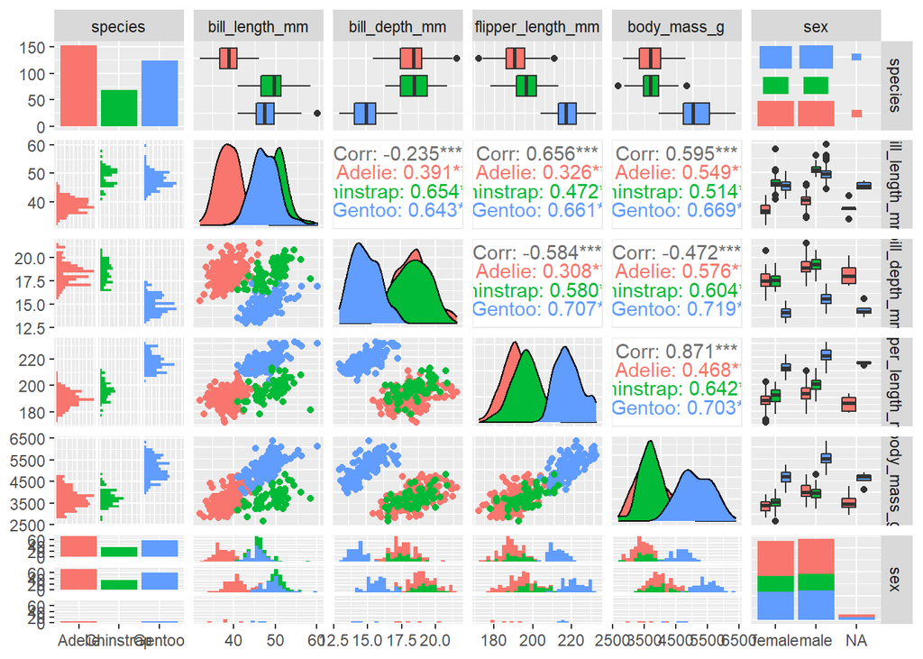

```r
penguins %>%
  select(species, bill_length_mm:sex) %>%
  GGally::ggpairs(aes(color = species))
```

## b. Make subset with Adelie and Chinstrap penguins

```r
# note species is a factor
class(penguins$species)
```

```
## [1] "factor"
```

```r
levels(penguins$species)
```

```
## [1] "Adelie"    "Chinstrap" "Gentoo"
```

```r
adelie_chinstrap <- penguins %>%
  filter(species %in% c("Adelie", "Chinstrap")) %>%
  mutate(species = fct_drop(species)) %>%
  select(-year) %>%
  drop_na()
# This will drop a factor level that doesn't appear (otherwise Gentoo will
# still show up as a factor level, even though there are no remaining
# observations for Gentoo penguins...)

# Check the levels (note here Adelie is before Chinstrap, so Adelie
# will be 0, Chinstrap will be 1)
class(adelie_chinstrap$species)
```

```
## [1] "factor"
```

```r
levels(adelie_chinstrap$species)
```

```
## [1] "Adelie"    "Chinstrap"
```

## c. Let’s just check out trends across variables for those two species

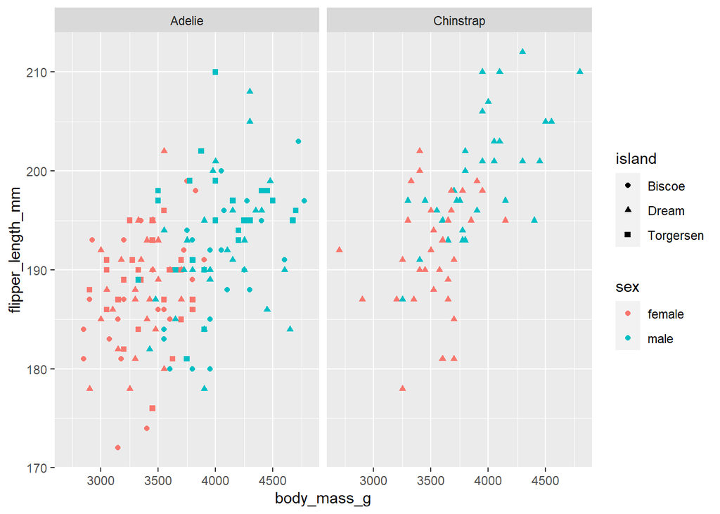

```r
ggplot(data = adelie_chinstrap, aes(x = body_mass_g, y = flipper_length_mm)) +
  geom_point(aes(color = sex, shape = island)) +
  facet_wrap(~species)
```

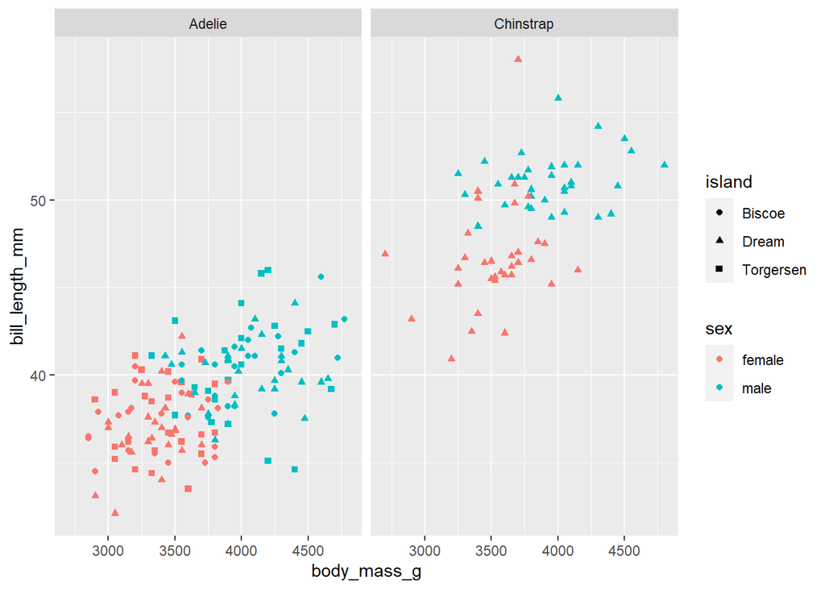

```r
ggplot(data = adelie_chinstrap, aes(x = body_mass_g, y = bill_length_mm)) +
  geom_point(aes(color = sex, shape = island)) +
  facet_wrap(~species)
```

## d. Binary logistic regression

Let’s first try to predict penguin species as a function of body mass, flipper length, and sex

```r
f1 <- species ~ body_mass_g + flipper_length_mm + sex


ad_chin_blr1 <- glm(formula = f1,
                    data = adelie_chinstrap,
                    family = "binomial")
```

```r
ad_chin_blr1
```

```
##
## Call:  glm(formula = f1, family = "binomial", data = adelie_chinstrap)
##
## Coefficients:
##       (Intercept)        body_mass_g  flipper_length_mm            sexmale
##        -3.161e+01         -8.576e-04          1.778e-01         -5.716e-01
##
## Degrees of Freedom: 213 Total (i.e. Null);  210 Residual
## Null Deviance:       267.6
## Residual Deviance: 226.4     AIC: 234.4
```

```r
summary(ad_chin_blr1)
```

```
##
## Call:
## glm(formula = f1, family = "binomial", data = adelie_chinstrap)
##
## Deviance Residuals:
##     Min       1Q   Median       3Q      Max
## -1.9456  -0.8195  -0.5581   1.0065   2.3698
##
## Coefficients:
##                     Estimate Std. Error z value Pr(>|z|)
## (Intercept)       -3.161e+01  5.784e+00  -5.465 4.63e-08 ***
## body_mass_g       -8.576e-04  5.428e-04  -1.580    0.114
## flipper_length_mm  1.778e-01  3.236e-02   5.495 3.91e-08 ***
## sexmale           -5.716e-01  4.499e-01  -1.270    0.204
## ---
## Signif. codes:  0 '***' 0.001 '**' 0.01 '*' 0.05 '.' 0.1 ' ' 1
##
## (Dispersion parameter for binomial family taken to be 1)
##
##     Null deviance: 267.57  on 213  degrees of freedom
## Residual deviance: 226.45  on 210  degrees of freedom
## AIC: 234.45
##
## Number of Fisher Scoring iterations: 4
```

```r
# Get a tidy version w/ broom:
blr1_tidy <- broom::tidy(ad_chin_blr1)
```

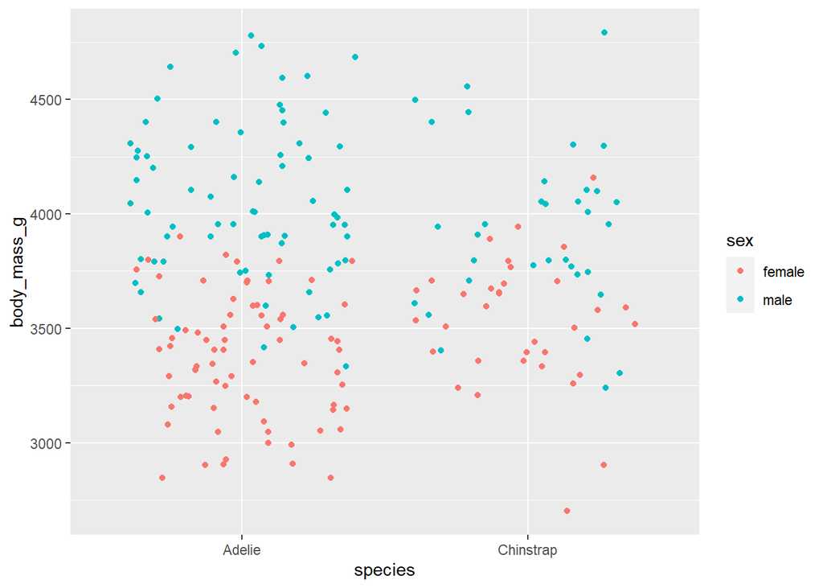

```r
ggplot(data = adelie_chinstrap, aes(x = species, y = body_mass_g)) +
  geom_jitter(aes(color = sex))
```

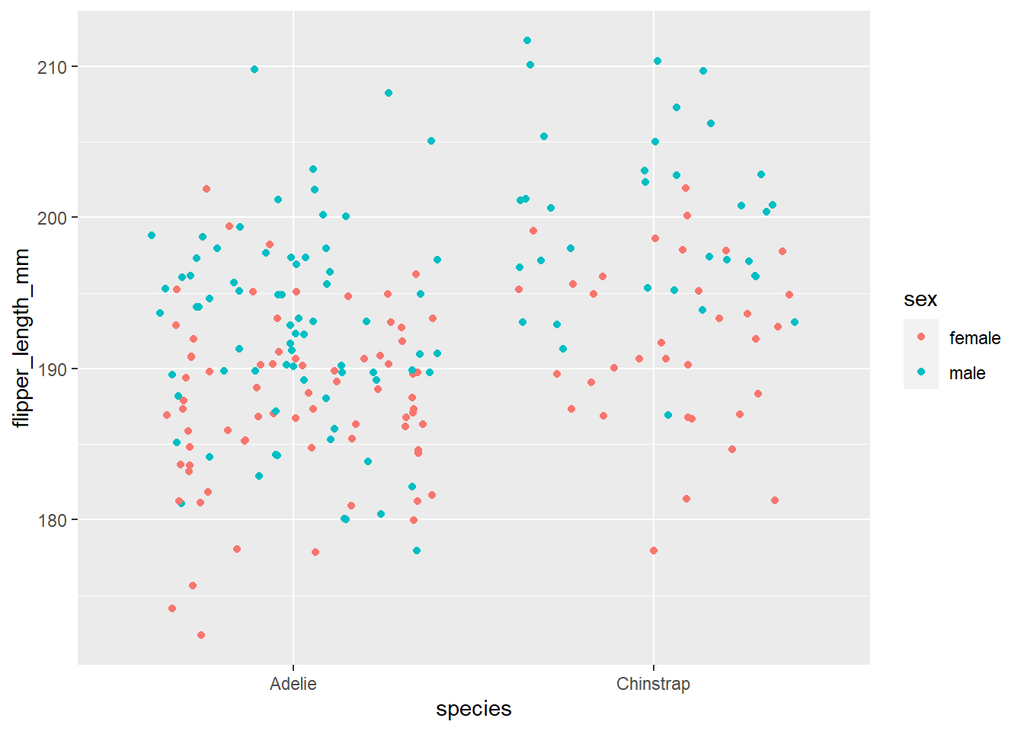

```r
ggplot(data = adelie_chinstrap, aes(x = species, y = flipper_length_mm)) +
  geom_jitter(aes(color = sex))
```

Adding `type.predict = "response"` here converts the log odds (link), the default reported, to the probability of being Chinstrap for each observation.

```r
blr1_fitted <- ad_chin_blr1 %>%
  broom::augment(type.predict = "response")
```

Let’s do a couple of quick visualizations, with flipper length (the only significant coefficient) on the x-axis and probability of being a Chinstrap on the y-axis:

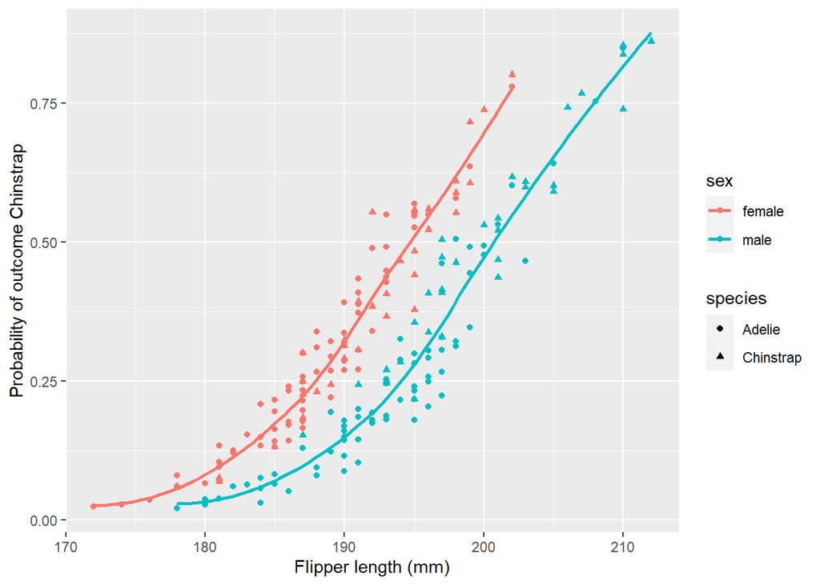

```r
ggplot(data = blr1_fitted, aes(x = flipper_length_mm, y = .fitted)) +
  # add aes(shape = species) to compare probability with actual
  geom_point(aes(color = sex, shape = species)) +
  # add geom_smooth to show general fit
  geom_smooth(aes(color = sex), se = FALSE) +
  labs(x = "Flipper length (mm)",
       y = "Probability of outcome Chinstrap")
```

## Predictions for new values with `predict()`

What is the probability that a female penguin weight 3410 g with a flipper length of 192 mm will be Chinstrap?

```r
ex_1 <- predict(ad_chin_blr1,
                data.frame(sex = "female",
                  body_mass_g = 3410,
                  flipper_length_mm = 192),
                # tell it type = 'response' to get prob, not log odds
                type = "response")

# Based on the model, the probability that this penguin is a Chinstrap is 0.4.
```

```r
new_df <- data.frame(
  sex = c("male", "male", "female"),
  body_mass_g = c(3298, 4100, 3600),
  flipper_length_mm = c(212, 175, 180)
)

ex_2 <- predict(ad_chin_blr1,
                    new_df,
                    type = "response")
```

## e. Binary logistic regression - new model

```r
f2 <- species ~ bill_length_mm + body_mass_g


ad_chin_blr2 <- glm(formula = f2,
                    data = adelie_chinstrap,
                    family = "binomial")
```

Look at the model:

```r
ad_chin_blr2
```

```
##
## Call:  glm(formula = f2, family = "binomial", data = adelie_chinstrap)
##
## Coefficients:
##    (Intercept)  bill_length_mm     body_mass_g
##      -68.15326         2.72188        -0.01371
##
## Degrees of Freedom: 213 Total (i.e. Null);  211 Residual
## Null Deviance:       267.6
## Residual Deviance: 17    AIC: 23
```

```r
summary(ad_chin_blr2)
```

```
##
## Call:
## glm(formula = f2, family = "binomial", data = adelie_chinstrap)
##
## Deviance Residuals:
##      Min        1Q    Median        3Q       Max
## -1.70697  -0.00556  -0.00023   0.00006   2.09831
##
## Coefficients:
##                  Estimate Std. Error z value Pr(>|z|)
## (Intercept)    -68.153259  25.041441  -2.722  0.00650 **
## bill_length_mm   2.721885   1.024164   2.658  0.00787 **
## body_mass_g     -0.013705   0.005647  -2.427  0.01523 *
## ---
## Signif. codes:  0 '***' 0.001 '**' 0.01 '*' 0.05 '.' 0.1 ' ' 1
##
## (Dispersion parameter for binomial family taken to be 1)
##
##     Null deviance: 267.572  on 213  degrees of freedom
## Residual deviance:  17.003  on 211  degrees of freedom
## AIC: 23.003
##
## Number of Fisher Scoring iterations: 11
```

```r
# Get a tidy version w/ broom:
blr2_tidy <- broom::tidy(ad_chin_blr2)
```

Let’s see if this makes sense based on a visual comparison:

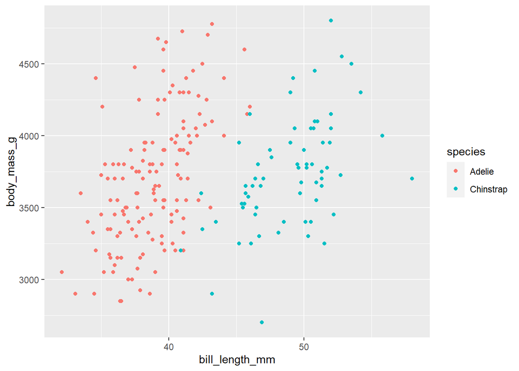

```r
ggplot(adelie_chinstrap, aes(x = bill_length_mm, y = body_mass_g)) +
  geom_point(aes(color = species))
```

## Model selection

Let’s compare the models using AICc and BIC

```r
AICcmodavg::aictab(list(ad_chin_blr1, ad_chin_blr2))
```

```
##
## Model selection based on AICc:
##
##      K   AICc Delta_AICc AICcWt Cum.Wt      LL
## Mod2 3  23.12       0.00      1      1   -8.50
## Mod1 4 234.64     211.52      0      1 -113.22
```

```r
AICcmodavg::bictab(list(ad_chin_blr1, ad_chin_blr2))
```

```
##
## Model selection based on BIC:
##
##      K    BIC Delta_BIC BICWt Cum.Wt      LL
## Mod2 3  33.10      0.00     1      1   -8.50
## Mod1 4 247.91    214.81     0      1 -113.22
```

And let’s compare with a 10-fold cross-validation, using prediction accuracy as our metric.

```r
set.seed(123)


n_folds <- 10
fold_vec <- rep(1:n_folds, length.out = nrow(adelie_chinstrap))
ad_chin_kfold <- adelie_chinstrap %>%
  mutate(fold = sample(fold_vec, size = n(), replace = FALSE))
```

# Tidymodels flow

## Tidymodels basic

```r
### Set the model type
?logistic_reg ### note glm is the default engine

blr_model <- logistic_reg() %>% ### also linear_reg, rand_forest, etc
  set_engine('glm')

### basic regression
blr_tidyfit_f1 <- blr_model %>%
  fit(f1, data = adelie_chinstrap)
blr_tidyfit_f2 <- blr_model %>%
  fit(f2, data = adelie_chinstrap)

### query the fitted models
blr_tidyfit_f1
```

```
## parsnip model object
##
##
## Call:  stats::glm(formula = species ~ body_mass_g + flipper_length_mm +
##     sex, family = stats::binomial, data = data)
##
## Coefficients:
##       (Intercept)        body_mass_g  flipper_length_mm            sexmale
##        -3.161e+01         -8.576e-04          1.778e-01         -5.716e-01
##
## Degrees of Freedom: 213 Total (i.e. Null);  210 Residual
## Null Deviance:       267.6
## Residual Deviance: 226.4     AIC: 234.4
```

```r
blr_tidyfit_f2
```

```
## parsnip model object
##
##
## Call:  stats::glm(formula = species ~ bill_length_mm + body_mass_g,
##     family = stats::binomial, data = data)
##
## Coefficients:
##    (Intercept)  bill_length_mm     body_mass_g
##      -68.15326         2.72188        -0.01371
##
## Degrees of Freedom: 213 Total (i.e. Null);  211 Residual
## Null Deviance:       267.6
## Residual Deviance: 17    AIC: 23
```

```r
### examine different outputs to see how well the models fit
blr_tidyfit_f1 %>%
  tidy()
```

```
## # A tibble: 4 × 5
##   term                estimate std.error statistic      p.value
##   <chr>                  <dbl>     <dbl>     <dbl>        <dbl>
## 1 (Intercept)       -31.6       5.78         -5.47 0.0000000463
## 2 body_mass_g        -0.000858  0.000543     -1.58 0.114
## 3 flipper_length_mm   0.178     0.0324        5.49 0.0000000391
## 4 sexmale            -0.572     0.450        -1.27 0.204
```

```r
blr_tidyfit_f1 %>%
  glance()
```

```
## # A tibble: 1 × 8
##   null.deviance df.null logLik   AIC   BIC deviance df.residual  nobs
##           <dbl>   <int>  <dbl> <dbl> <dbl>    <dbl>       <int> <int>
## 1          268.     213  -113.  234.  248.     226.         210   214
```

## Tidymodels crossfold validation

```r
### set seed for reproducibility! here to set the folds
set.seed(345)

tidy_folds <- vfold_cv(adelie_chinstrap, v = 10)
tidy_folds
```

```
## #  10-fold cross-validation
## # A tibble: 10 × 2
##    splits           id
##    <list>           <chr>
##  1 <split [192/22]> Fold01
##  2 <split [192/22]> Fold02
##  3 <split [192/22]> Fold03
##  4 <split [192/22]> Fold04
##  5 <split [193/21]> Fold05
##  6 <split [193/21]> Fold06
##  7 <split [193/21]> Fold07
##  8 <split [193/21]> Fold08
##  9 <split [193/21]> Fold09
## 10 <split [193/21]> Fold10
```

```r
### use a workflow that bundles the logistic model and a formula
# blr_model <- logistic_reg() %>%
#   set_engine('glm')

blr_tidy_wf1 <- workflow() %>%
  add_model(blr_model) %>%
  add_formula(f1)

blr_tidy_cv_f1 <- blr_tidy_wf1 %>%
  fit_resamples(tidy_folds)

### use functions from the tune package to extract metrics
collect_metrics(blr_tidy_cv_f1)
```

```
## # A tibble: 2 × 6
##   .metric  .estimator  mean     n std_err .config
##   <chr>    <chr>      <dbl> <int>   <dbl> <chr>
## 1 accuracy binary     0.729    10  0.0299 Preprocessor1_Model1
## 2 roc_auc  binary     0.755    10  0.0409 Preprocessor1_Model1
```

```r
#   .metric  .estimator  mean     n std_err .config
#   <chr>    <chr>      <dbl> <int>   <dbl> <chr>
# 1 accuracy binary     0.828    10 0.00739 Preprocessor1_Model1
# 2 roc_auc  binary     0.902    10 0.00808 Preprocessor1_Model1

### We'll talk about roc_auc next week!


### Repeat for model 2 - let students do this on their own!
blr_tidy_wf2 <- workflow() %>%
  add_model(blr_model) %>%
  add_formula(f2)

blr_tidy_cv_f2 <- blr_tidy_wf2 %>%
  fit_resamples(tidy_folds)

### use functions from the tune package to extract metrics
collect_metrics(blr_tidy_cv_f2)
```

```
## # A tibble: 2 × 6
##   .metric  .estimator  mean     n std_err .config
##   <chr>    <chr>      <dbl> <int>   <dbl> <chr>
## 1 accuracy binary     0.967    10 0.0121  Preprocessor1_Model1
## 2 roc_auc  binary     0.998    10 0.00132 Preprocessor1_Model1
```

## Area under the curve!

Receiver Operating Characteristic Curve (ROC Curve) compares the diagnostic ability of a binary classifier (like logistic regression) based on the discrimination threshold. Up to now (and for homework) we’ve been using a 50% threshold by default. The ROC can tell us tradeoffs between true positive rate and false positive rate as we change the threshold, and also can give a great indication of model quality.

It seems like model 2 is far better than model 1 in this instance.

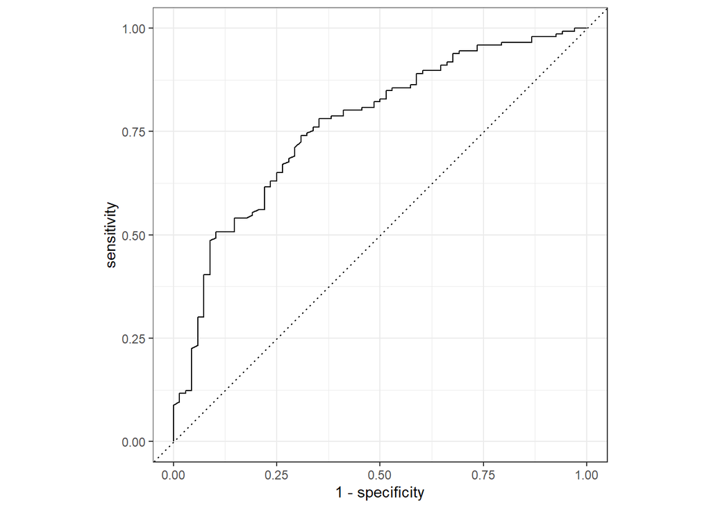

```r
### This is copied from above, for reference
# blr_model <- logistic_reg() %>% ### also linear_reg, rand_forest, etc
#   set_engine('glm')
#
# ### basic regression
# blr_tidyfit_f1 <- blr_model %>%
#   fit(f1, data = adelie_chinstrap)
# blr_tidyfit_f2 <- blr_model %>%
#   fit(f2, data = adelie_chinstrap)

blr_f1_pred <- adelie_chinstrap %>%
  mutate(predict(blr_tidyfit_f1, .),
         predict(blr_tidyfit_f1, ., type = 'prob'))

blr_f1_pred %>%
  roc_curve(truth = species, .pred_Adelie) %>%
  autoplot()
```

```r
blr_f1_pred %>%
  roc_auc(truth = species, .pred_Adelie)
```

```
## # A tibble: 1 × 3
##   .metric .estimator .estimate
##   <chr>   <chr>          <dbl>
## 1 roc_auc binary         0.766
```

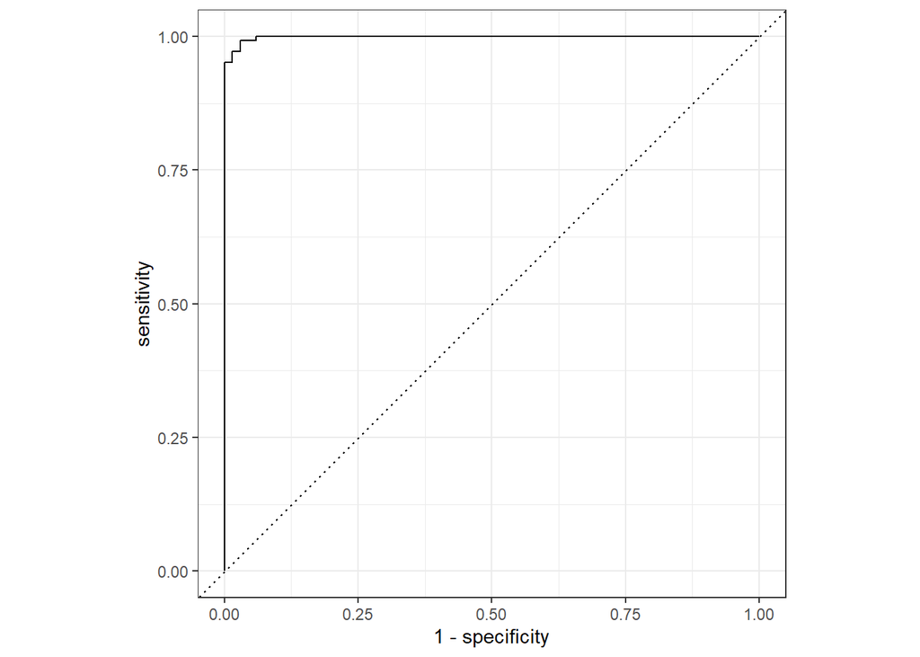

```r
### Students repeat for blr_tidyfit_f2 and compare!
blr_f2_pred <- adelie_chinstrap %>%
  mutate(predict(blr_tidyfit_f2, .),
         predict(blr_tidyfit_f2, ., type = 'prob'))

blr_f2_pred %>%
  roc_curve(truth = species, .pred_Adelie) %>%
  autoplot()
```

```r
blr_f2_pred %>%
  roc_auc(truth = species, .pred_Adelie)
```

```
## # A tibble: 1 × 3
##   .metric .estimator .estimate
##   <chr>   <chr>          <dbl>
## 1 roc_auc binary         0.999
```

# End Part 1